# Homework Week 6:

Franziska Lampart

October 31, 2016

#### Question 2

The first 1000 “Genes”" have an expression change of either -2 or +2 in the second half of the samples (group 2).

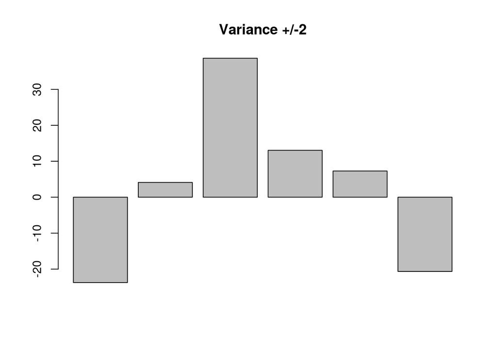

```r
barplot(y[1, 1:6], main = "Variance +/-2")
```

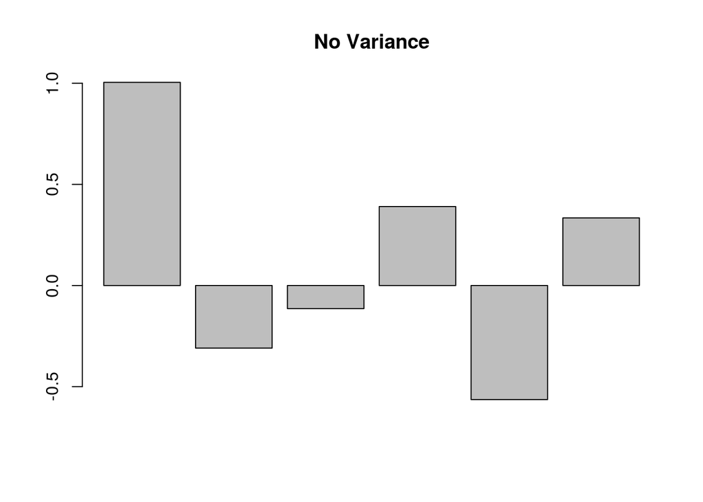

```r
barplot(y[1001, 1:6], main = "No Variance")
```

#### Question 3

First column (intercept): y-axis intercept

Second column (grp): Group membership

```
##   (Intercept) grp
## 1           1   0
## 2           1   0
## 3           1   0
## 4           1   1
## 5           1   1
## 6           1   1
## attr(,"assign")
## [1] 0 1
```

#### Question 4.

```r
classicalt <- c()
classicalp <- c() #needet later in Question 6
for (i in c(1:nGenes)){
  var <- t.test(y[i,1:3], y[i,4:6], var.equal = TRUE)
  classicalt[i] <- var$statistic
  classicalp[i] <- var$p.value
}
```

#### Question 5.

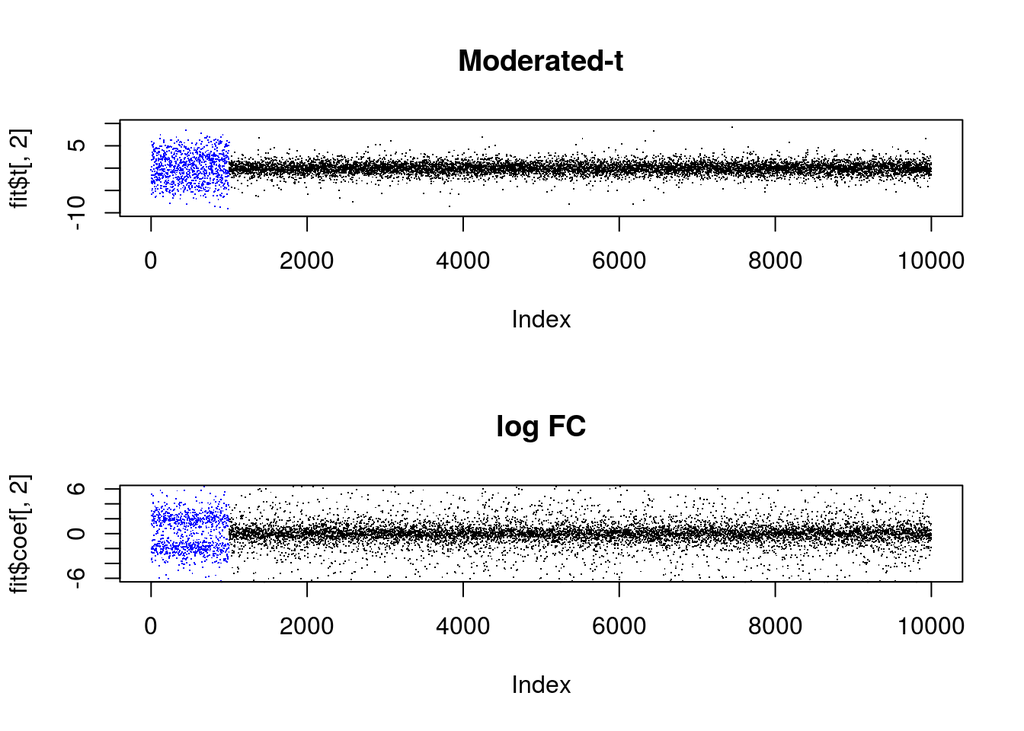

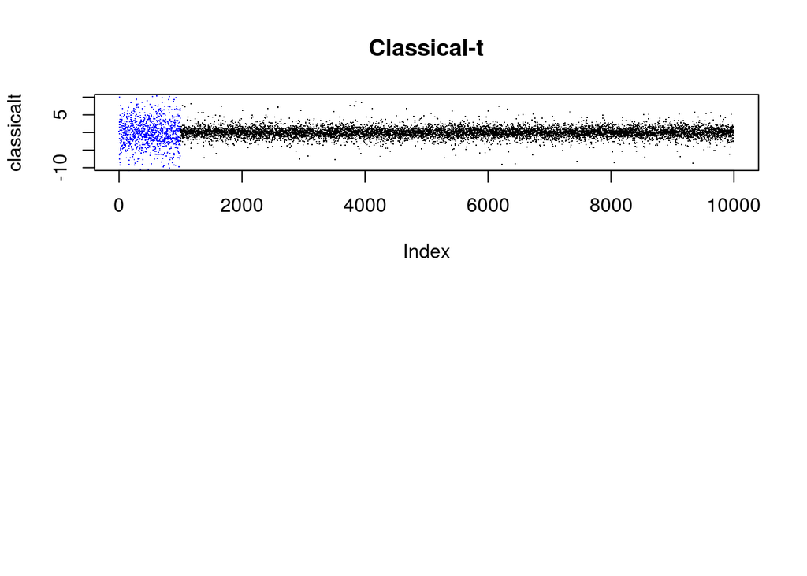

The moderated t-test and the classical t-test look very similar under this conditions, with a big dispersion of values in the first 1000 samples and a lower dispersion for the rest of the samples. In the log FC we can see a separation in two to groups (-2 and +2).

#### Question 6.

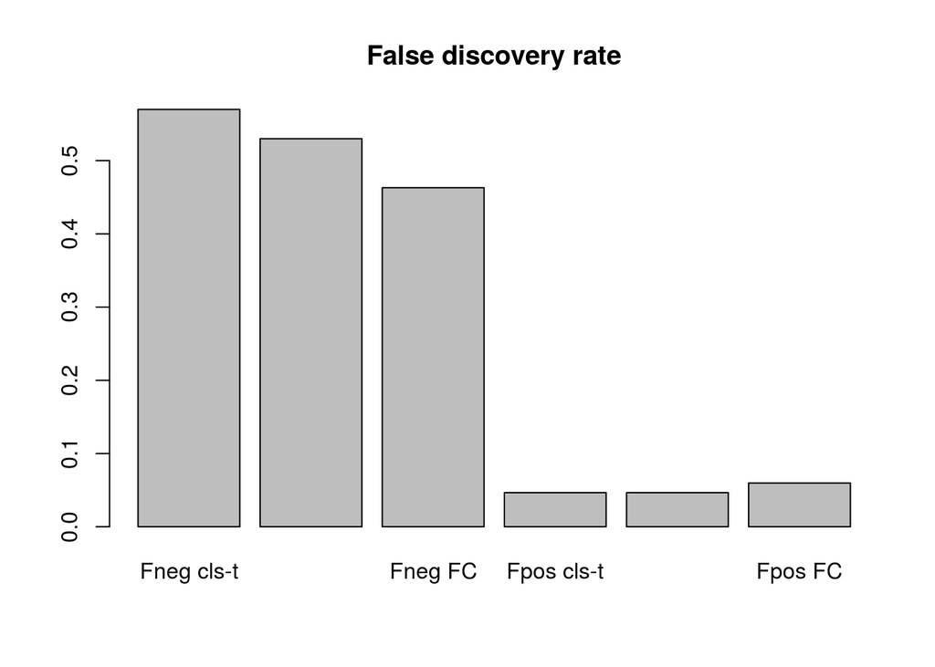

```r
# Ratio of false negatives:
Clp_fneg <- sum(classicalp[1:length(diff)] > 0.05)
Fp_fneg <- sum(fit$p.value[1:length(diff), 2] > 0.05)
FC_fneg <- 1000-(sum(fit$coefficients[1:length(diff),2] > 2) +
                   sum(fit$coefficients[1:length(diff),2] < -2))
ratio_fneg <- c(Clp_fneg, Fp_fneg, FC_fneg)/length(diff)
# Ratio of false positives:
Clp_fpos <- sum(classicalp[(length(diff)+1):nGenes] < 0.05)
Fp_fpos <- sum(fit$p.value[(length(diff)+1):nGenes, 2] < 0.05)
FC_fpos <- (sum(fit$coefficients[1:length(diff),2] > 2) +
                   sum(fit$coefficients[1:length(diff),2] < -2))
ratio_fpos <- c(Clp_fpos, Fp_fpos, FC_fpos)/(nGenes-length(diff))

barplot(c(ratio_fneg, ratio_fpos), main = "False discovery rate",
        names.arg=c("Fneg cls-t", "Fneg mod-t", "Fneg FC", "Fpos cls-t", "Fpos mod-t", "Fpos FC"))
```

All methods have a higher false negative rate than false positive. Surprisingly the FC has the lowest false negative rate, however in context of false positive it performs the worst.

#### Question 7

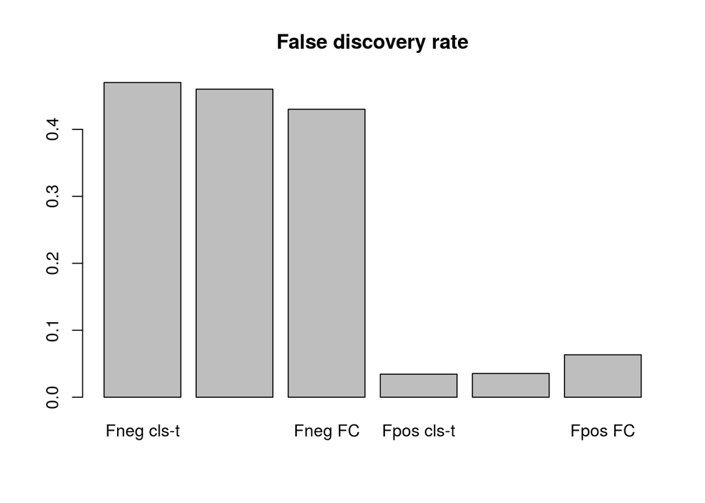

If the number of genes are reduced FC performs still the best in context of false negative but hast the highest false positive rate. The same is true when we decrease the number of samples to 4. However here the overall false discovery rates increases.

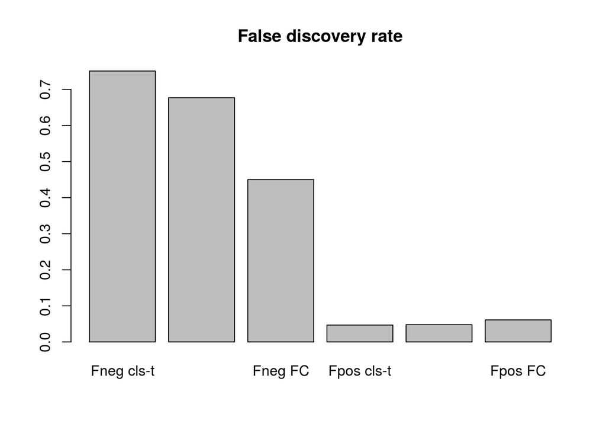